# Predictive model for Belesar dam

Eduardo Roman y Óscar García

17/4/2019

# 1 Indroduction

In this document the progress achived in the development of the predictive model for the streamflow of Belesar Dam during the last weeks will be explained.

For this purpose we count with a historical data from january of 2018 to februrary of 2019. It should be note that the quality of the data was medium-low, with very noisy data and also a lot of outliers, such as, negative values in the streamflow dataset.

For the elaboration of this predicctive model we will use ARW-WRF model rain output. It’s remarkable that we are getting very good correlations between WRF model data and the historical data. Maybe the best noticce is that the best correlation is for the long-term cumulative rain results.

All the procces is being carried out using R and Rstudio tools, because of it’s verstatility and good performance for machine learning purposes. The first predictive models that we have elaborate are being developed using common regression techniques, but the are getting good performance only for the next 3 days. For getting a good long-term prediction, more sofisticated methods should be implemented.

Nowadays, we are calculating the best predictive model for achieved a good performance for a long-term prediction. For this purpose we are using the R “caret” package that is and recognized tool for machine learning using R lenguaje. For getting the best model using this tool we are using cross-validation techniques for more that 45 algorithms, integrated in caret package. After the best algorithms are being selected, another procces for adjusting the parameters will be carried out.

# 2 Hourly rainfall comparation between observed and estimated

This figure shows that ARW-WRF model that we are running is getting good rainfall predicction.

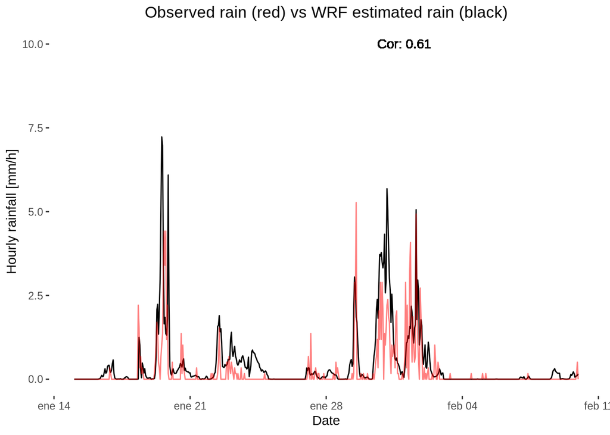

# 3 Daily rainfall comparation between observed and estimated, cumulative and streamflow.

This figure shows that WRF model is even better in the daily rainfall stimation and also in the total cumulative rain. Also, this figure shows that the streamflow is highly correlated whith the rainfall with some lag.

```
## $`-8.04904174804688__42.5383224487305`
```

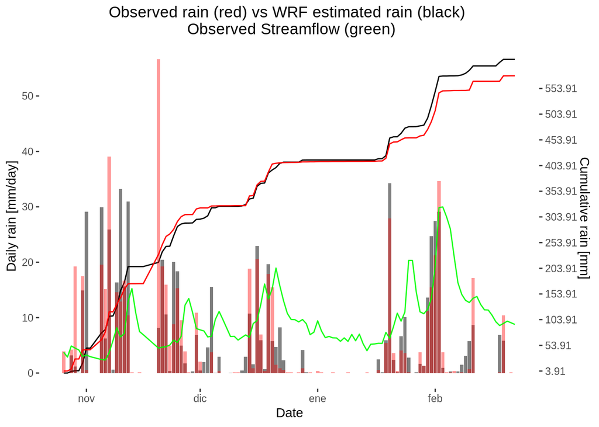

# 4 Dam level and streamflow prediccion using basic machine learning techniques

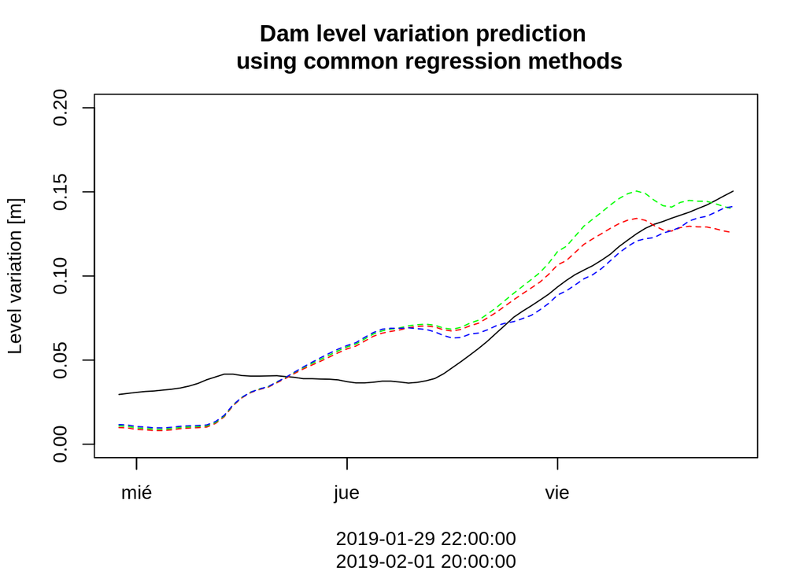

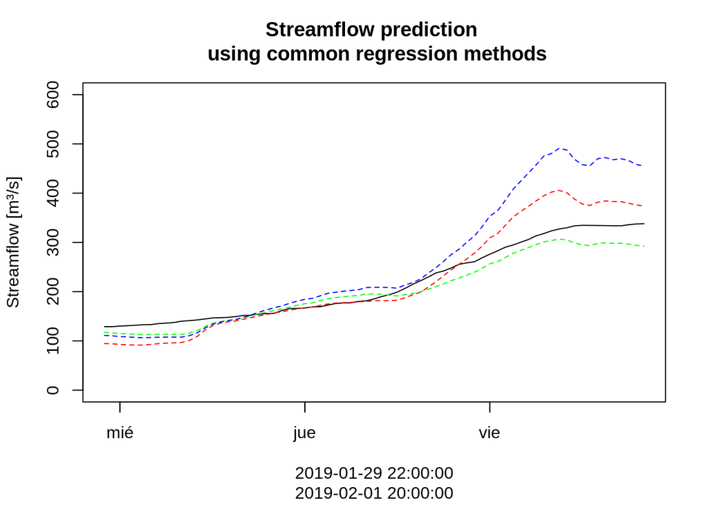

# 5 Dam level and streamflow prediccion using complex machine learning algorithms

In the next table all the complex algorithms that are going to be tested using R “caret” package are shown.

|  | Method | type |
| --- | --- | --- |
| 6 | ANFIS | Regression |
| 20 | blasso | Regression |
| 21 | blassoAveraged | Regression |
| 22 | bridge | Regression |
| 23 | brnn | Regression |
| 36 | cubist | Regression |
| 39 | DENFIS | Regression |
| 46 | enet | Regression |
| 51 | FIR.DM | Regression |
| 52 | foba | Regression |

[output cut: 38 more lines]

All the tests needed are not actually made but, this is one of the first results using Adaptive neuro fuzzy inference system (ANFIS).

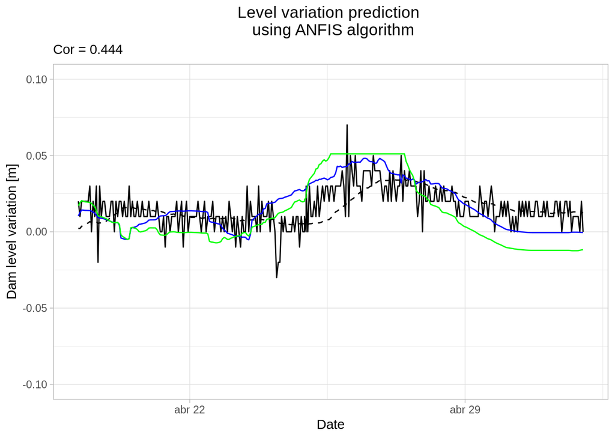